# Code Review/Debugging Code

2025-05-27

## The Assignment:

*Tip: View this in the visual editor in RStudio*

You want to re-create the HTML document in the `data/` folder in this repo titled `01-debugging_code.html`. Below is the workflow to do so, *however* you will notice if you attempt to render this R Markdown document as is, it does NOT reproduce the `01-debugging_code_output.html` file, and it won’t even render until you fix some of the mistakes/missing elements. Therefore, this workflow is not reproducible! Your task is to fix the below coding workflow so that it renders and **exactly** matches the output of `01-debugging_code_output.html` (*including* whether or not certain code chunks and/or outputs are shown).

There are a total of **5 fixes** you need to make to the workflow below. To complete this assignment you must *1)* Identify the 5 errors and specify what they are below (*1 pt each*) and *2)* fix the errors and render this entire .Rmd as am HTML doc where the content below matches that of the `01-debugging_code_output.html` (*5 pts*).

**List here the 5 errors you had to fix in this workflow:**

## The workflow you need to fix begins here:

#### The NOAA Atlantic Hurricane Dataset

This exploratory workflow uses the `atlantic_storms.csv` file in the data folder for this lesson. This dataset is based on the NOAA Atlantic hurricane database (https://www.nhc.noaa.gov/data/#hurdat). The data includes storm tracks of storms from 1975-2021, as well as some characteristics (like wind and air pressure) during their progression. Storms from 1979 onward are measured every six hours during the lifetime of the storm. Storms in earlier years have some missing data. Descriptions of each variable in the dataset can be found in `data/atlantic_storms_desc.txt`.

We read in the data and initially explore its structure:

```
##      name                year          month             day
##  Length:19066       Min.   :1975   Min.   : 1.000   Min.   : 1.00
##  Class :character   1st Qu.:1993   1st Qu.: 8.000   1st Qu.: 8.00
##  Mode  :character   Median :2004   Median : 9.000   Median :16.00
##                     Mean   :2002   Mean   : 8.699   Mean   :15.78
##                     3rd Qu.:2012   3rd Qu.: 9.000   3rd Qu.:24.00
##                     Max.   :2021   Max.   :12.000   Max.   :31.00
##
##       hour             lat             long            status
##  Min.   : 0.000   Min.   : 7.00   Min.   :-109.30   Length:19066
##  1st Qu.: 5.000   1st Qu.:18.40   1st Qu.: -78.70   Class :character
##  Median :12.000   Median :26.60   Median : -62.25   Mode  :character
##  Mean   : 9.094   Mean   :26.99   Mean   : -61.52
##  3rd Qu.:18.000   3rd Qu.:33.70   3rd Qu.: -45.60
##  Max.   :23.000   Max.   :70.70   Max.   :  13.50
##
##     category          wind           pressure      tropicalstorm_force_diameter
##  Min.   :1.000   Min.   : 10.00   Min.   : 882.0   Min.   :   0.0
##  1st Qu.:1.000   1st Qu.: 30.00   1st Qu.: 987.0   1st Qu.:   0.0
##  Median :1.000   Median : 45.00   Median :1000.0   Median : 110.0
##  Mean   :1.898   Mean   : 50.02   Mean   : 993.6   Mean   : 146.3
##  3rd Qu.:3.000   3rd Qu.: 65.00   3rd Qu.:1007.0   3rd Qu.: 220.0
##  Max.   :5.000   Max.   :165.00   Max.   :1024.0   Max.   :1440.0
##  NA's   :14382                                     NA's   :9512
##  hurricane_force_diameter
##  Min.   :  0.00
##  1st Qu.:  0.00
##  Median :  0.00
##  Mean   : 14.81
##  3rd Qu.:  0.00
##  Max.   :300.00
##  NA's   :9512
```

Let’s first explore wind speed across all the different storm types with a histogram:

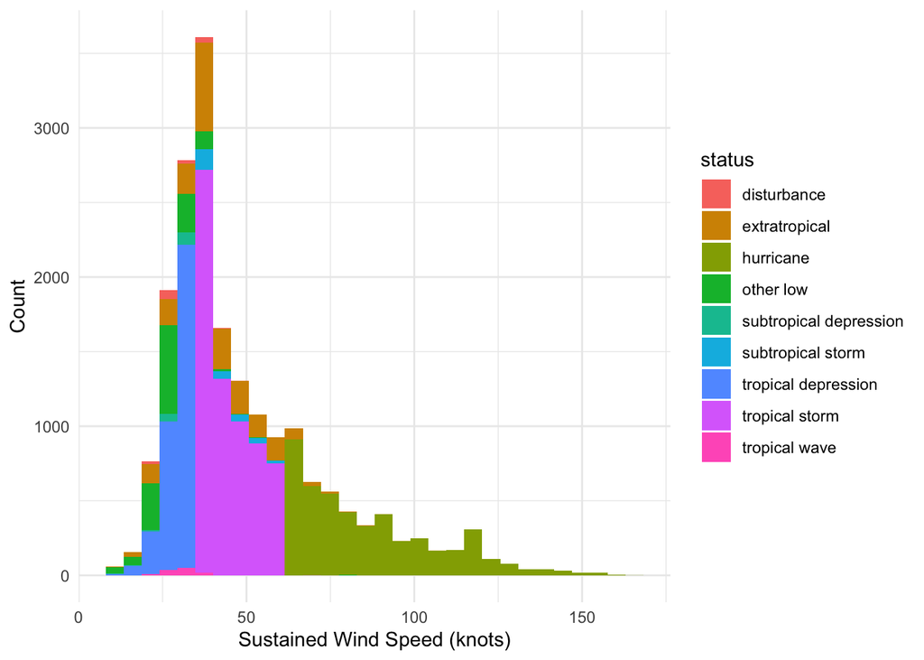

Now we want to visualize the relationship between pressure and wind speed *across latitudes*, where higher latitudes (blue) indicate locations further north:

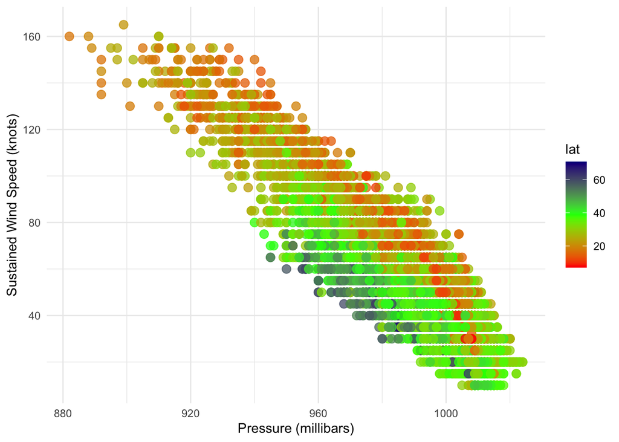

Finally, let’s visualize each hurricane’s maximum diameter through the years:

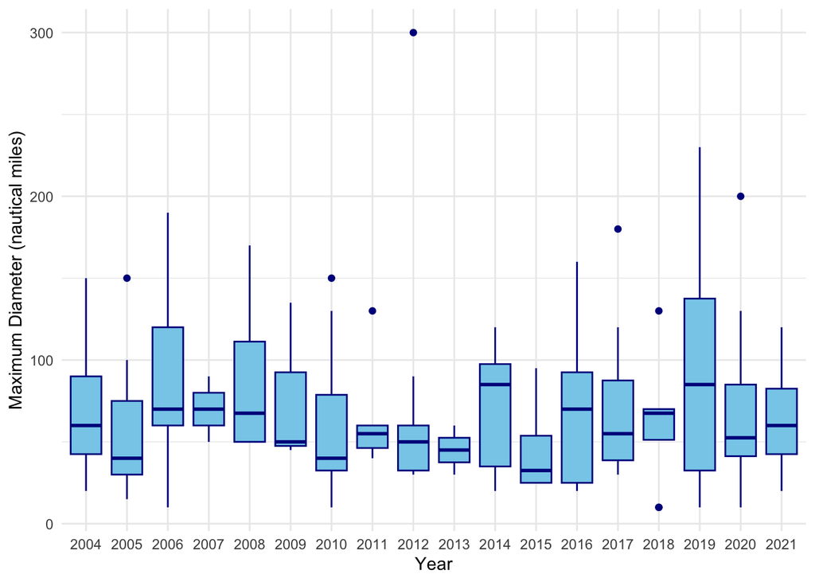